```r
# Vector de mascotas
mascotas <- c('loro', 'perro', 'gato', 'gallina', 'hamster', 'cerdo', 'ternero', 'caballo', 'cabra')

# Agregar 20 mascotas más
mascotas <- c(mascotas, 'conejo', 'tortuga', 'pez', 'canario', 'hurón', 'iguana', 'serpiente', 'ratón', 'araña', 'camaleón', 'pato', 'pavo', 'oveja', 'vaca', 'burro', 'ganso', 'paloma', 'cisne', 'lagarto', 'erizo')

# Shuffle the mascotas vector
mascotas <- sample(mascotas)

# Seleccionar una muestra aleatoria de 3 elementos sin repetición
selmascota <- sample(mascotas, 3)
selmascota[3]
```

[1] “pavo”

```r
nombremascota1 <- selmascota[1]
nombremascota2 <- selmascota[2]
nombremascota3 <- selmascota[3]

# Crear secuencia del 60 al 300 de 10 en 10
numeros <- seq(60, 600, 10)

# Eliminamos el número 100 del vector
numeros_sin_100 <- setdiff(numeros, 100)
numeros_sin_100
```

[1] 60 70 80 90 110 120 130 140 150 160 170 180 190 200 210 220 230 240 250 [20] 260 270 280 290 300 310 320 330 340 350 360 370 380 390 400 410 420 430 440 [39] 450 460 470 480 490 500 510 520 530 540 550 560 570 580 590 600

```r
# Ahora hacemos el muestreo de este nuevo vector
enkuestados <- sample(numeros_sin_100, 1)
```

```r
# Generar tres números para los porcentajes. Su suma siempre debe ser igual a 100
generar_vector_unico <- function() {
  repetir <- TRUE
  while (repetir) {
    # Generar el primer número como un múltiplo de 5 entre 5 y 60.
    # Esto aumenta las posibilidades de tener tres números únicos.
    primer_numero <- sample(seq(5, 60, by = 5), 1)

    # Calcular el máximo valor posible para el segundo número,
    # asegurándose de que haya espacio para un tercer número único.
    max_segundo_numero <- 95 - primer_numero

    # Generar el segundo número asegurando que sea diferente al primero
    posibles_segundos <- seq(5, max_segundo_numero, by = 5)
    posibles_segundos <- posibles_segundos[posibles_segundos != primer_numero]
    if (length(posibles_segundos) > 0) {
      segundo_numero <- sample(posibles_segundos, 1)
    } else {
      next
    }

    # Calcular el tercer número necesario para que la suma sea 100,
    # asegurándose de que sea diferente a los dos anteriores.
    tercer_numero <- 100 - primer_numero - segundo_numero

    # Verificar si los tres números son únicos
    if (length(unique(c(primer_numero, segundo_numero, tercer_numero))) == 3) {
      repetir <- FALSE
    }
  }

  # Crear el vector
  vector <- c(primer_numero, segundo_numero, tercer_numero)

  return(vector)
}

# Generar y mostrar el vector de porcentajes
vector_resultado <- generar_vector_unico()
vector_resultado
```

[1] 10 5 85

```r
# El vector_resultado contiene tres porcentajes únicos que suman 100.

mashor <- max(vector_resultado)
mashor
```

[1] 85

```r
porxentaje1 <- vector_resultado[1]
porxentaje2 <- vector_resultado[2]
porxentaje3 <- vector_resultado[3]
####################################################

maskota1 <- (enkuestados*vector_resultado[1])/100 # Número de personas que adoptan maskota1
maskota1
```

[1] 30

```r
maskota2 <- (enkuestados*vector_resultado[2])/100
maskota2
```

[1] 15

```r
maskota3 <- (enkuestados*vector_resultado[3])/100
maskota3
```

[1] 255

```r
mashiormaskota <- max(maskota1, maskota2, maskota3)
mashiormaskota
```

[1] 255

```r
image01 <- '
\\begin{tikzpicture}
  \\node{
\\begin{tabular}{|l|c|}
\\hline
\\textbf{Animal} & \\textbf{Porcentaje de personas } \\\\
     & \\textbf{interesadas en adoptar} \\\\ \\hline
     %s & %s \\\\ \\hline
     %s & %s \\\\ \\hline
     %s & %s \\\\ \\hline
\\end{tabular}
};
\\end{tikzpicture}
'

demas <- sample

image01 <-sprintf(image01, selmascota[1], porxentaje1, selmascota[2], porxentaje2, selmascota[3], porxentaje3)
```

# Question

El líder de un programa de adopción de mascotas encuestó a 300 personas para conocer qué animal les interesaría adoptar. Del total de encuestados, el 10% adoptaría un iguana, el 5% adoptaría un(a) ternero y el 85% adoptaría un(a) pavo.

¿Cuál de las siguientes representaciones muestra correctamente la información recolectada en la encuesta?

## Answerlist

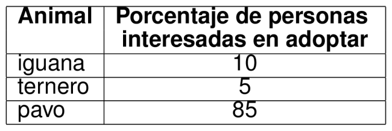

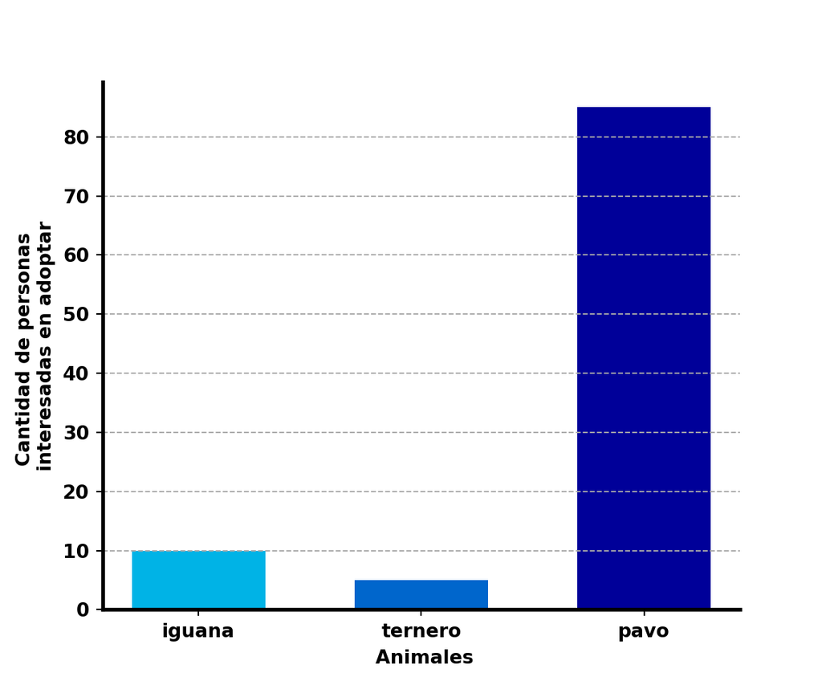

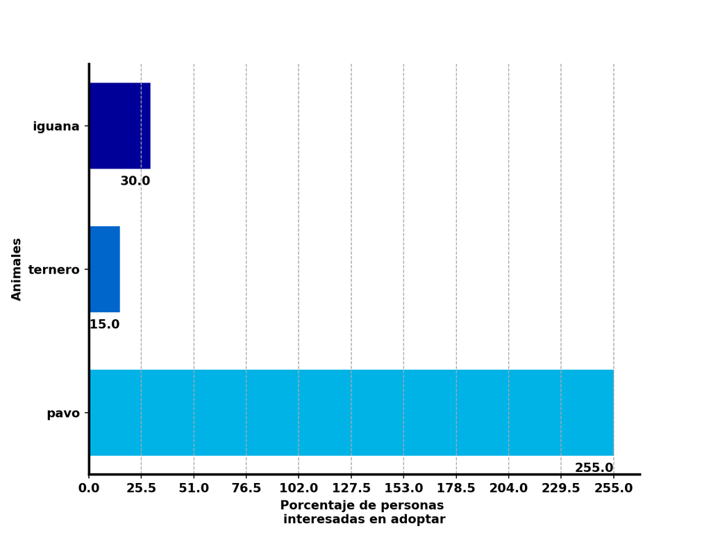

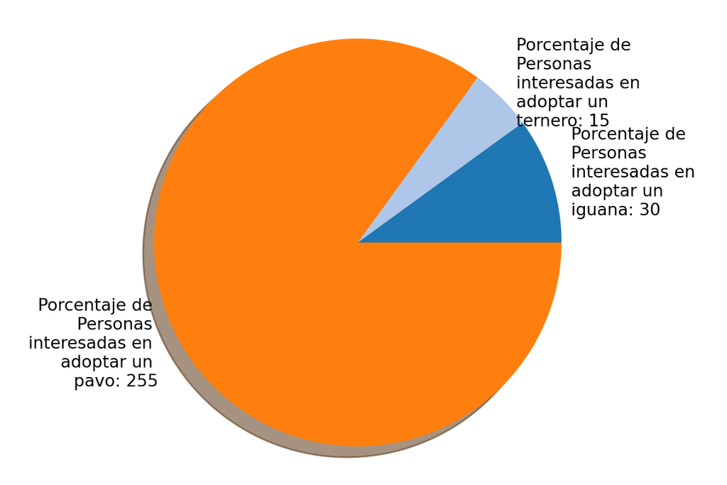

# Solution

Esta tabla representa la información recolectada en la encuesta, mostrando el porcentaje de personas interesadas en adoptar cada tipo de mascota:

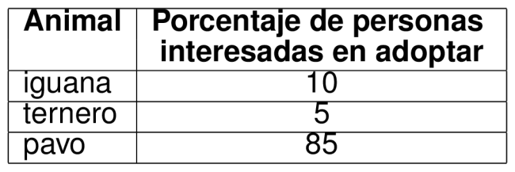

# Meta-information

exname: I_1796473/2023-Cuadernillo-Matematicas-11-2(single-choice) extype: schoice exsolution: 1000 exshuffle: TRUE